# Estimating respiratory losses (SI 3)

Tim Rademacher

09/09/2019

## Estimating respiratory losses for stem sections

To estimate stem respiratory losses, weekly stem respiration measurements were made using a Li-Cor820 starting at 13.00h. The LiCor820 was attached to a PVC pipe (4" diameter) that were previously fitted and attached to the stem sections using silicone to create a closed chamber in which the enclosed air circulates via a small pump, similar to the Flux Puppy system (Carbone et al., 2019). Respiration fluxes and uncertainties were calculate from the change in CO<sub>2</sub> using the RespChamberProc package (Perez-Priego et al., 2015) in R (R Core Team, 2019). The rates were corrected for fluctuations in atmospheric water vapour pressure using climate data from the Fisher meteorological station. Stem sections were measured in the same order every week to minimise variations in time of day of repeat measurements.

## Integration over the surface area of the stem section

Instantaneous fluxes of diffusive CO<sub>2</sub> loss through the bark were measured as described above and subsequently integrated across space (e.g. the specific surface area of a 10 cm stem section) for each stem section to estimate the respiratrory loss in grams per stem section per day. To integrate the measured respiration rates across a 10cm stem section, we calculate the surface area of the i-th stem section ($A_{s,i}$) as follows:

$$A_{s, i} = \frac {cbh_{s,i}} {100} \times h$$
, where is the $cbh_{s,i}$ is the circumference in cemtimeters and $h$ is the height of the section in meters (here $h = 0.1$m).

The stem respiration rate over this surface area was then determined by multiplication of the instanteanous respiration flux (in $g \, m^{-2} \,day^{-1}$) by the surface area to get the respiration rate (in $g \, day_{-1}$).

```r
# get the tree measurements of circumference from spreadsheet
#----------------------------------------------------------------------------------------
allometricData <- read_excel (path = '/media/tim/dataDisk/PlantGrowth/data/allometry/Exp2017/allometricDataExp2017.xlsx',
                              sheet = 'allometricData',
                              na = "NA")

# define height of the section (h; in m)
#--------------------------------------------------------------------------------------
h <- 0.1

# create a tibble with the responseVariables
#--------------------------------------------------------------------------------------
if (!exists ('responseVariables')) {
  responseVariables <- tibble (year  = 2017,
                               month = c (rep (7, 40), rep (8, 40),
                                          rep (10, 40), rep (11, 40)),
                               tree = rep (1:40, 4),
                               resp250 = NA, resp200 = NA, resp150 = NA,    resp100 = NA,
                               resp50 = NA, A250 = NA, A200 = NA, A150 = NA, A100 = NA,
                               A50 = NA)
} else {
  if ("resp150" %in% colnames (responseVariables)) {
    responseVariables <- responseVariables %>% select (-c (resp50, resp100, resp150, resp200, resp250, A250, A200, A150, A100, A50))
  }
  responseVariables <-  add_column (responseVariables, resp250 = NA, resp200 = NA,
                                    resp150 = NA,   resp100 = NA, resp50 = NA, A250 = NA,
                                    A200 = NA, A150 = NA, A100 = NA, A50 = NA)
}
# loop over each treeto calculate surface area for each section
#----------------------------------------------------------------------------------------
for (r in 1:dim (responseVariables) [1]) {
  iTree <- responseVariables [['tree']] [r]

  # Check whether this tree has only one chamber (i.e. control group)
  #--------------------------------------------------------------------------------------
  if (allometricData [['treatment']] [allometricData [['tree']] == iTree] == 1) {
    responseVariables [['A150']] [r] <-
      allometricData [['cbh150']] [allometricData [['tree']] == iTree] / 100.0 * h

  # Check whether this tree has two chambers (i.e. gridled or single compression)
  #--------------------------------------------------------------------------------------
  } else if (allometricData [['treatment']] [allometricData [['tree']] == iTree] == 2 |
             allometricData [['treatment']] [allometricData [['tree']] == iTree] == 3) {
    responseVariables [['A100']] [r] <-
      allometricData [['cbh100']] [allometricData [['tree']] == iTree] / 100.0 * h
    responseVariables [['A200']] [r] <-
      allometricData [['cbh200']] [allometricData [['tree']] == iTree] / 100.0 * h

  # check whether this tree has three chambers (i.e. double compression)
  #--------------------------------------------------------------------------------------
  } else if (allometricData [['treatment']] [allometricData [['tree']] == iTree] == 4) {
    responseVariables [['A50']]  [r] <-
      allometricData [['cbh50']]  [allometricData [['tree']] == iTree] / 100.0 * h
    responseVariables [['A150']] [r] <-
      allometricData [['cbh150']] [allometricData [['tree']] == iTree] / 100.0 * h
    responseVariables [['A250']] [r] <-
      allometricData [['cbh250']] [allometricData [['tree']] == iTree] / 100.0 * h
  }
}

# read processed the respiration data
#----------------------------------------------------------------------------------------
source ('../stemCO2Efflux/readProcessedRespData.R')

# source function to convert units from RespChamberFlux package
#----------------------------------------------------------------------------------------
source ('../stemCO2Efflux/RespChamberProc/R/convertUnits.R')

# read 2017 respiration rates derived using RespChamberProc package.
#----------------------------------------------------------------------------------------
respRates2017 <- filter (respData, study == 'Exp2017' & tree <= 40); rm (respData)

# convert flux from micro mol per second per square meter to g per square meter per day
#----------------------------------------------------------------------------------------
respRates2017 [['fluxRaw_g']] <- convert_mumolPers_to_gPerday (respRates2017 [['fluxRaw']])

# integrate the respiration rate over space
#----------------------------------------------------------------------------------------
respRates2017 <- add_column (respRates2017, fluxRaw_g_day = NA)

# loop over all trees to calculate the respiration flux in g per day
#----------------------------------------------------------------------------------------
for (iTree in 1:40) {

  # check whether this tree has only one chamber (i.e. control group)
  #--------------------------------------------------------------------------------------
  if (allometricData [['treatment']] [allometricData [['tree']] == iTree] == 1) {
    respRates2017 [['fluxRaw_g_day']] [respRates2017 [['tree']] == iTree] <- respRates2017 [['fluxRaw_g']] [respRates2017 [['tree']] == iTree] * unique (responseVariables [['A150']] [responseVariables [['tree']] == iTree])
  # check whether this tree has two chambers (i.e. girdled and compressed group)
  #--------------------------------------------------------------------------------------
  } else if (allometricData [['treatment']] [allometricData [['tree']] == iTree] == 2 |
             allometricData [['treatment']] [allometricData [['tree']] == iTree] == 3) {
    condition <- respRates2017 [['tree']] == iTree & respRates2017 [['chamber']] == 1
    respRates2017 [['fluxRaw_g_day']] [condition] <-
      respRates2017 [['fluxRaw_g']] [condition] *
      unique (responseVariables [['A100']] [responseVariables [['tree']] == iTree])

    condition <- respRates2017 [['tree']] == iTree & respRates2017 [['chamber']] == 2
    respRates2017 [['fluxRaw_g_day']] [condition] <-
      respRates2017 [['fluxRaw_g']] [condition] *
      unique (responseVariables [['A200']] [responseVariables [['tree']] == iTree])
  # check whether this tree has three chambers (i.e. double compressed group)
  #--------------------------------------------------------------------------------------
  } else if (allometricData [['treatment']] [allometricData [['tree']] == iTree] == 4) {
    condition <- respRates2017 [['tree']] == iTree & respRates2017 [['chamber']] == 1
    respRates2017 [['fluxRaw_g_day']] [condition] <-
      respRates2017 [['fluxRaw_g']] [condition] *
      unique (responseVariables [['A50']] [responseVariables [['tree']] == iTree])
    condition <- respRates2017 [['tree']] == iTree & respRates2017 [['chamber']] == 2
    respRates2017 [['fluxRaw_g_day']] [condition] <-
      respRates2017 [['fluxRaw_g']] [condition] *
      unique (responseVariables [['A150']] [responseVariables [['tree']] == iTree])
    condition <- respRates2017 [['tree']] == iTree & respRates2017 [['chamber']] == 3
    respRates2017 [['fluxRaw_g_day']] [condition] <-
      respRates2017 [['fluxRaw_g']] [condition] *
      unique (responseVariables [['A250']] [responseVariables [['tree']] == iTree])
  }
}
```

# Integrate across time

Respiration rates were averaged for over four time periods: (i) pre-treatment, (ii) treatment period 1 (i.e. first month after start of the experiment), (iii) treament period 2 (i.e. second and third month after the start of the experiment) and (iii) treatment period 3 (i.e. fourth month after the start of the experiment to the end of the growing season).

We then approximated the total loss of carbon for each combination of period $j$ and stem section $i$ ($R_{i,j}$) by multiplying the temporal mean of spatially integrated respiration rates in $g \, day^{-1}$ measured during each period $j$ by the length of the period ($l_p$ in days).

$$R_{i,j} = \frac {1} {n} \sum_{k=1}^{n} R_{i,k} \times l_p$$
, where n is the number of weekly sampling dates during each period.

```r
# set period boundaries
#----------------------------------------------------------------------------------------
boundaries <- as.POSIXct (c ('2017-07-05','2017-08-10','2017-10-09','2017-11-01'), tz = 'EST')

# calculate the geometric mean for each period for each stem section
#----------------------------------------------------------------------------------------
for (period in 1:4) {
  if (period == 1) {
    periodData <- filter (respRates2017, respRates2017 [['timestamp']] <= boundaries [period])
    pLen <- boundaries [period] - as.POSIXct (min (periodData [['timestamp']]), tz = 'EST')
  } else if (period > 1 & period < 5) {
    periodData <- filter (respRates2017, respRates2017 [['timestamp']] > boundaries [period-1] &
                                         respRates2017 [['timestamp']] <= boundaries [period])
    pLen <- boundaries [period] - boundaries [period-1]
  }

  # aggregate the mean respiration over each period by chamber and tree (g day-1)
  #--------------------------------------------------------------------------------------
  tmpResp <- periodData %>%
    group_by (tree, chamber) %>%
    summarize (meanResp = mean (fluxRaw_g_day, na.rm = T))

  # add a period column to temporary tibble
  #--------------------------------------------------------------------------------------
  tmpResp$period <- period

  # multiply mean respiration rate by length of period to get the total respiratory carbon loss (g period-1)
  #--------------------------------------------------------------------------------------
  tmpResp$totalResp <- tmpResp$meanResp * as.numeric (pLen, 'days')

  # add the period specific data to the responseVariables tibble
  #--------------------------------------------------------------------------------------
  for (iTree in 1:40){
    condition <- responseVariables [['month']] == month (boundaries [period]) &
                 responseVariables [['tree']]  == iTree
    if (allometricData [['treatment']] [iTree] == 1) {
      responseVariables [['resp150']] [condition] <- tmpResp [['totalResp']] [tmpResp [['tree']] == iTree]
    } else if (allometricData [['treatment']] [iTree] == 2 |
               allometricData [['treatment']] [iTree] == 3) {
      responseVariables [['resp100']] [condition] <-
        tmpResp [['totalResp']] [tmpResp [['tree']] == iTree & tmpResp [['chamber']] == 1]
      responseVariables [['resp200']] [condition] <-
        tmpResp [['totalResp']] [tmpResp [['tree']] == iTree & tmpResp [['chamber']] == 2]
    } else if (allometricData [['treatment']] [iTree] == 4) {
      responseVariables [['resp50']]  [condition] <-
        tmpResp [['totalResp']] [tmpResp [['tree']] == iTree & tmpResp [['chamber']] == 1]
      responseVariables [['resp150']] [condition] <-
        tmpResp [['totalResp']] [tmpResp [['tree']] == iTree & tmpResp [['chamber']] == 2]
      responseVariables [['resp250']] [condition] <-
        tmpResp [['totalResp']] [tmpResp [['tree']] == iTree & tmpResp [['chamber']] == 3]
    }
  }
}

# write response variable as a csv file
#----------------------------------------------------------------------------------------
WRITE <- TRUE; if (WRITE) write_csv (x = responseVariables, path = 'respiratoryLosses.csv')
```

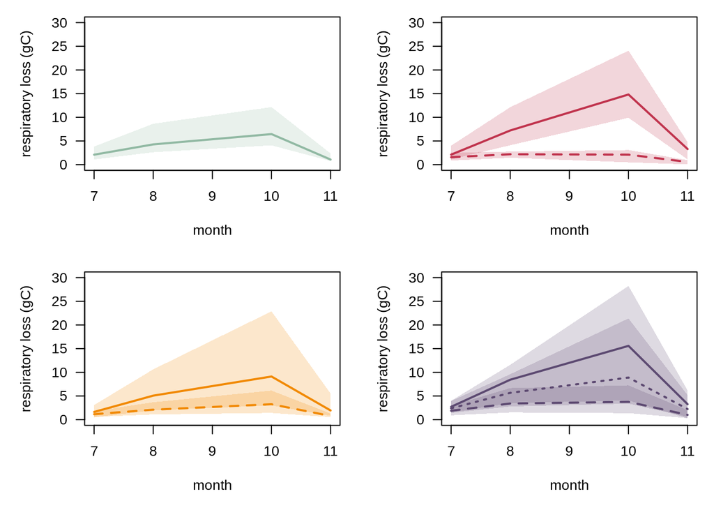

```r
# add treatments to the responseVariables
#----------------------------------------------------------------------------------------
responseVariables <- add_column (responseVariables, treatment = rep (allometricData [['treatment']] [1:40], 4))

# calculate mean
#----------------------------------------------------------------------------------------
suppressWarnings (tmp50  <- responseVariables %>% group_by (month, treatment) %>%
                                                  summarise (mean = mean (resp50, na.rm = T),
                                                             min = min (resp50, na.rm = T),
                                                             max = max (resp50, na.rm = T)))
suppressWarnings (tmp100 <- responseVariables %>% group_by (month, treatment) %>%
                                                  summarise (mean = mean (resp100, na.rm = T),
                                                             min = min (resp100, na.rm = T),
                                                             max = max (resp100, na.rm = T)))
suppressWarnings (tmp150 <- responseVariables %>% group_by (month, treatment) %>%
                                                  summarise (mean = mean (resp150, na.rm = T),
                                                             min = min (resp150, na.rm = T),
                                                             max = max (resp150, na.rm = T)))
suppressWarnings (tmp200 <- responseVariables %>% group_by (month, treatment) %>%
                                                  summarise (mean = mean (resp200, na.rm = T),
                                                             min = min (resp200, na.rm = T),
                                                             max = max (resp200, na.rm = T)))
suppressWarnings (tmp250 <- responseVariables %>% group_by (month, treatment) %>%
                                                  summarise (mean = mean (resp250, na.rm = T),
                                                             min = min (resp250, na.rm = T),
                                                             max = max (resp250, na.rm = T)))

# plot respiration losses
#----------------------------------------------------------------------------------------
par (mfrow = c (2, 2))
par (mar = c (5,5,1,1))
plot (x = tmp150 [['month']] [tmp150 [['treatment']] == 1],
      y = tmp150 [['mean']] [tmp150 [['treatment']] == 1],
      xlab = 'month', ylab  = 'respiratory loss (gC)', las = 1,
      typ = 'l', lwd = 2,
      col = tColours [['colour']] [1],
      ylim =  c (0, 30))
polygon (x = c (tmp150 [['month']] [tmp150 [['treatment']] == 1],
                rev (tmp150 [['month']] [tmp150 [['treatment']] == 1])),
        y = c (tmp150 [['max']] [tmp150 [['treatment']] == 1],
               rev (tmp150 [['min']] [tmp150 [['treatment']] == 1])),
        col = '#91b9a433', lty = 0)
plot (x = tmp100 [['month']] [tmp100 [['treatment']] == 2],
       y = tmp100 [['mean']]  [tmp100 [['treatment']] == 2],
      xlab = 'month', ylab  = 'respiratory loss (gC)', las = 1,
      typ = 'l', lwd = 2, lty = 2,
      col = tColours [['colour']] [2],
      ylim =  c (0, 30))
polygon (x = c (tmp100 [['month']] [tmp100 [['treatment']] == 2],
                rev (tmp100 [['month']] [tmp100 [['treatment']] == 2])),
        y = c (tmp100 [['max']] [tmp100 [['treatment']] == 2],
               rev (tmp100 [['min']] [tmp100 [['treatment']] == 2])),
        col = '#C0334D33', lty = 0)
lines (x = tmp200 [['month']] [tmp200 [['treatment']] == 2],
       y = tmp200 [['mean']]  [tmp200 [['treatment']] == 2],
       lty = 1, lwd = 2, col = tColours [['colour']] [2])
polygon (x = c (tmp200 [['month']] [tmp200 [['treatment']] == 2],
                rev (tmp200 [['month']] [tmp200 [['treatment']] == 2])),
        y = c (tmp200 [['max']] [tmp200 [['treatment']] == 2],
               rev (tmp200 [['min']] [tmp200 [['treatment']] == 2])),
        col = '#C0334D33', lty = 0)
plot (x = tmp100 [['month']] [tmp100 [['treatment']] == 3],
       y = tmp100 [['mean']]  [tmp100 [['treatment']] == 3],
      xlab = 'month', ylab  = 'respiratory loss (gC)', las = 1,
      typ = 'l', lwd = 2, lty = 2,
      col = tColours [['colour']] [3],
      ylim =  c (0, 30))
polygon (x = c (tmp100 [['month']] [tmp100 [['treatment']] == 3],
                rev (tmp100 [['month']] [tmp100 [['treatment']] == 3])),
        y = c (tmp100 [['max']] [tmp100 [['treatment']] == 3],
               rev (tmp100 [['min']] [tmp100 [['treatment']] == 3])),
        col = '#F1890433', lty = 0)
lines (x = tmp200 [['month']] [tmp200 [['treatment']] == 3],
       y = tmp200 [['mean']]  [tmp200 [['treatment']] == 3],
       lty = 1, lwd = 2, col = tColours [['colour']] [3])
polygon (x = c (tmp200 [['month']] [tmp200 [['treatment']] == 3],
                rev (tmp200 [['month']] [tmp200 [['treatment']] == 3])),
        y = c (tmp200 [['max']] [tmp200 [['treatment']] == 3],
               rev (tmp200 [['min']] [tmp200 [['treatment']] == 3])),
        col = '#F1890433', lty = 0)
plot (x = tmp50 [['month']] [tmp50 [['treatment']] == 4],
       y = tmp50 [['mean']]  [tmp50 [['treatment']] == 4],
      xlab = 'month', ylab  = 'respiratory loss (gC)', las = 1,
      typ = 'l', lwd = 2, lty = 2,
      col = tColours [['colour']] [4],
      ylim =  c (0, 30))
polygon (x = c (tmp50 [['month']] [tmp50 [['treatment']] == 4],
                rev (tmp50 [['month']] [tmp50 [['treatment']] == 4])),
        y = c (tmp50 [['max']] [tmp50 [['treatment']] == 4],
               rev (tmp50 [['min']] [tmp50 [['treatment']] == 4])),
        col = '#5C4A7233', lty = 0)
lines (x = tmp150 [['month']] [tmp150 [['treatment']] == 4],
       y = tmp150 [['mean']]  [tmp150 [['treatment']] == 4],
      col = tColours [['colour']] [4], lwd = 2, lty = 3)
polygon (x = c (tmp150 [['month']] [tmp150 [['treatment']] == 4],
                rev (tmp150 [['month']] [tmp150 [['treatment']] == 4])),
        y = c (tmp150 [['max']] [tmp150 [['treatment']] == 4],
               rev (tmp150 [['min']] [tmp150 [['treatment']] == 4])),
        col = '#5C4A7233', lty = 0)
lines (x = tmp250 [['month']] [tmp250 [['treatment']] == 4],
       y = tmp250 [['mean']]  [tmp250 [['treatment']] == 4],
      col = tColours [['colour']] [4], lwd = 2, lty = 1)
polygon (x = c (tmp250 [['month']] [tmp250 [['treatment']] == 4],
                rev (tmp150 [['month']] [tmp250 [['treatment']] == 4])),
        y = c (tmp250 [['max']] [tmp250 [['treatment']] == 4],
               rev (tmp250 [['min']] [tmp250 [['treatment']] == 4])),
        col = '#5C4A7233', lty = 0)
```

# References

Carbone, M.S., Seyednasrollah, B., Rademacher, T.T., Basler, D., Le Moine, J.M., Beals, S., Beasley, J., Greene, A., Kelroy, J., Richardson, A.D., 2019. Flux Puppy – An open-source software application and portable system design for low-cost manual measurements of CO2 and H2O fluxes. Agricultural and Forest Meteorology 274, 1–6.

Perez-Priego, O., Guan, J., Rossini, M., Fava, F., Wutzler, T., Moreno, G., Carvalhais, N., Carrara, A., Kolle, O., Julitta, T., Schrumpf, M., Reichstein, M., Migliavacca, M., 2015. Sun-induced chlorophyll fluorescence and photochemical reflectance index improve remote-sensing gross primary production estimates under varying nutrient availability in a typical Mediterranean savanna ecosystem. Biogeosciences 12, 6351–6367.

R Core Team, 2019. R: A Language and Environment for Statistical Computing. R Foundation for Statistical Computing, Vienna, Austria.